# Spiral Plots

Derenik Haghverdian

05 November, 2020

```r
library(tidyverse)
theme_set(theme_bw())
library(ggpubr)
```

# 1 Spiral Plot

Our goal is to create a figure similar to Figure 1.1.

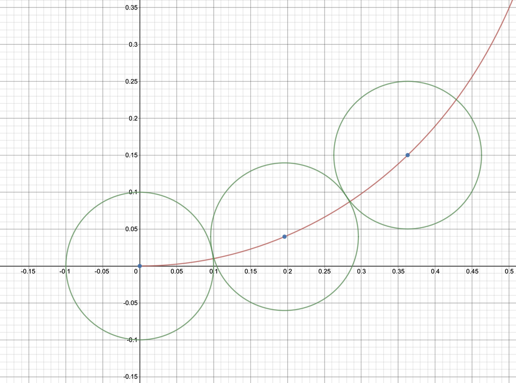

Figure 1.1: Spiral plot created with Desmos.com

We need to put $N$ circles on the spiral with equation $r = \theta$ such that the circles intersect with each other only at a single point and their centers lie on the spiral.

Let $R$ be the radius of these circles, and $\mathbf{c}^{(i)}$ be the center of circle $i$. Since the spiral starts from the origin, we can put the first circle at the origin, $\mathbf{c}^{(i)} = (0, 0)$.

Based on Figure 1.1:

$$\lVert \mathbf{c}^{(2)} - \mathbf{c}^{(1)} \lVert_2 = \lVert \mathbf{c}^{(3)} - \mathbf{c}^{(2)} \lVert_2 = \dots = \lVert \mathbf{c}^{(N)} - \mathbf{c}^{(N - 1)} \lVert_2 = 2 R$$

Hence, we can find $\mathbf{c} ^ {(i)}$ by the applying the Pythagorean theorem and solving for $r$:

$$\begin{aligned}
\left( \mathbf{c}^{(i + 1)}_x - \mathbf{c}^{(i)}_x \right)^2 + \left( \mathbf{c}^{(i + 1)}_y - \mathbf{c}^{(i)}_y \right)^2 & = 4 R^2
\end{aligned}$$

which in polar coordinates is equivalent to:

$$\begin{aligned}
\left( r_{i + 1} \cos r_{i + 1} - \mathbf{c}^{(i)}_x \right)^2 + \left( r_{i + 1} \sin r_{i + 1} - \mathbf{c}^{(i)}_y \right)^2 & = 4 R^2
\end{aligned}$$

where $r_{i + 1} \in \{ r_i, 2 R + r_i \}$.

# 2 Creating Spiral Plots

## 2.1 Finding the Center of the Next Circle

```r
find_centers <- function(N, R) {

  centers <- matrix(0, nrow = N, ncol = 2)

  # lower and upper bound of `r`
  int_lower <- 0.001
  int_upper <- 2 * R + int_lower

  for (n in 2:N) {
    eq <- uniroot(f =
                    function(r)
                      (r * cos(r) - centers[n - 1, 1])^2 +
                      (r * sin( r) - centers[n - 1, 2])^2 -
                      4 * R ^ 2,
                  lower = int_lower,
                  upper = int_upper)

    r <- eq$root
    centers[n, ] <- c(r * cos(r), r * sin(r))

    int_lower <- r
    int_upper <- 2 * R + r
  }

  centers
}
```

## 2.2 Plotting the Circles on the Spiral

```r
create_spiral_plot <- function(N, R = 0.05) {

  centers <- find_centers(N = N, R = R)

  fig <- ggplot(data = tibble(theta = seq(0, 2 * pi, length.out = 30),
                              x = R * cos(theta) + centers[1, 1],
                              y = R * sin(theta) + centers[1, 2]),
                aes(x = x, y = y)) +
    geom_path() +
    coord_fixed() +
    theme_void()

  for (n in 2:N) {
    fig <- fig +
      geom_path(data = tibble(theta = seq(0, 2 * pi,
                                          length.out = 100),
                              x = R * cos(theta) + centers[n, 1],
                              y = R * sin(theta) + centers[n, 2]),
                aes(x = x, y = y))
    }

  fig
}
```

## 2.3 Example

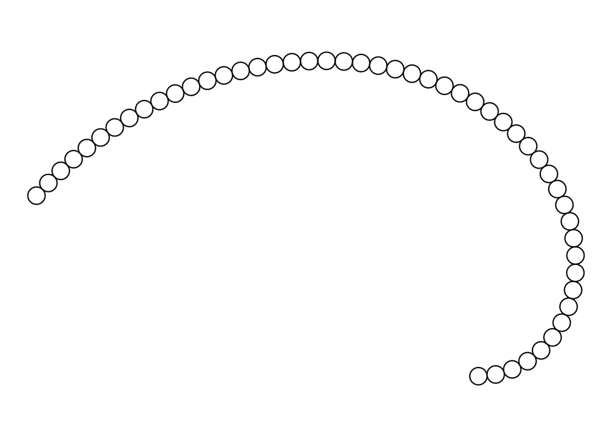

Figure 2.1: Spiral plot with 50 circles

```r
create_spiral_plot(N = 50)
```

We see that in Figure 2.1 that the spiral needs to be squeezed such that it is tighter and the circles are closer to each other.

To make the spiral tighter, we need to change the equation of the spiral to:

$$r = \tau \theta$$

where $\tau$ controls the overall size of the spiral. In this case, the equations change to:

$$\begin{aligned}
\left( r_{i + 1} \cos \tau r_{i + 1} - \mathbf{c}^{(i)}_x \right)^2 + \left( r_{i + 1} \sin \tau r_{i + 1} - \mathbf{c}^{(i)}_y \right)^2 & = 4 R^2
\end{aligned}$$

where $r_{i + 1} \in \{ r_i, 2 R + r_i \}$.

# 3 Creating Spiral Plots with Tightness Control

## 3.1 Finding the Center of All Circle

```r
find_centers <- function(N, R = 0.05, tau = 60) {

  centers <- matrix(0, nrow = N, ncol = 2)

  int_lower <- 0.001
  int_upper <- 2 * R + int_lower

  for (n in 2:N) {

    eq <- uniroot(f =
                    function(r)
                      (r * cos(tau * r) - centers[n - 1, 1])^2 +
                      (r * sin(tau * r) - centers[n - 1, 2])^2 -
                      4 * R ^ 2,
                  lower = int_lower,
                  upper = int_upper)

    r <- eq$root
    centers[n, ] <- c(r * cos(tau * r), r * sin(tau * r))

    int_lower <- r
    int_upper <- 2 * R + r
  }

  centers
}
```

## 3.2 Plotting the Circles on the Spiral with Tightness Control

```r
create_spiral_plot <- function(N, R = 0.05, tau = 60) {

  centers <- find_centers(N = N, R = R, tau = tau)

  fig <- ggplot(data = tibble(theta = seq(0, 2 * pi, length.out = 100),
                              x = R * cos(theta) + centers[1, 1],
                              y = R * sin(theta) + centers[1, 2]),
                aes(x = x, y = y)) +
    geom_path() +
    coord_fixed() +
    xlim(-0.8, 0.8) +
    ylim(-0.8, 0.8) +
    theme_void()

  for (n in 2:N) {
    fig <- fig +
      geom_path(data = tibble(theta = seq(0, 2 * pi,
                                          length.out = 30),
                              x = R * cos(theta) + centers[n, 1],
                              y = R * sin(theta) + centers[n, 2]),
                aes(x = x, y = y))
    }

  fig
}
```

## 3.3 Example

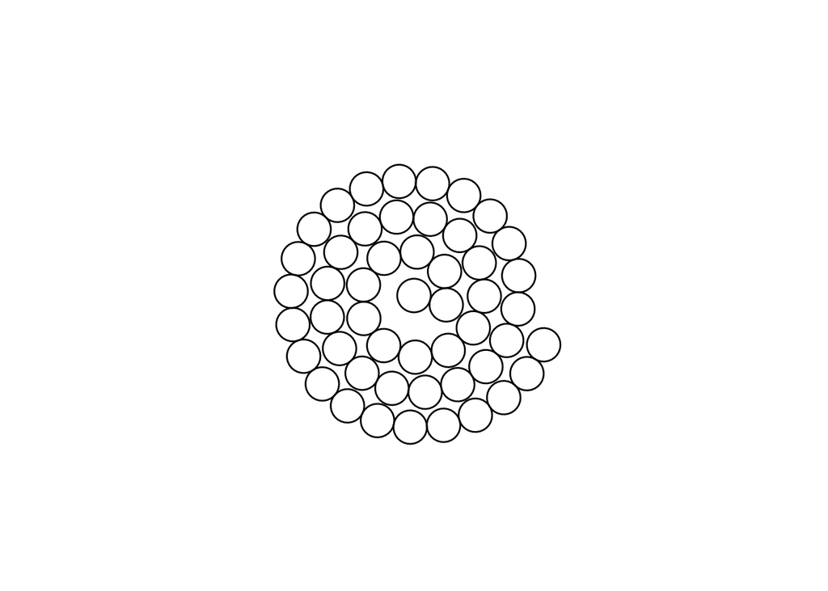

Figure 3.1: A tighter spiral plot with 50 circles

```r
create_spiral_plot(N = 50)
```

We see that in Figure 3.1 that the spiral is tighter now and the circles are closer to each other.

# 4 Creating Spiral Plots from Real Data

## 4.1 Spiral-plots for Real Data

```r
odor_b_counts <- c(55, 34, 34, 14, 20, 26, 16, 26, 37, 30,
                   71, 130, 132, 159, 117, 75, 58, 53, 47, 68,
                   23, 28, 31, 23, 48, 76, 92, 90, 93, 64,
                   61, 18, 13, 14, 25, 33, 44, 41, 33, 48)

odor_c_counts <- c(41, 22, 14, 13, 12, 14, 12, 14, 18, 28,
                   51, 85, 70, 43, 26, 22, 19, 17, 17, 36,
                   23, 27, 60, 72, 70, 64, 66, 58, 80, 53,
                   50, 31, 21, 37, 57, 65, 68, 76, 50, 48)

odor_d_counts <- c(23, 28, 12, 11, 7, 10, 9, 17, 22, 25,
                   48, 55, 38, 33, 23, 19, 23, 20, 24, 46,
                   28, 24, 54, 48, 59, 55, 43, 51, 55, 35,
                   67, 59, 62, 74, 77, 82, 91, 78, 65, 60)
```

```r
odor_b_figs <- list()
odor_c_figs <- list()
odor_d_figs <- list()

for (i in 1:length(odor_b_counts)) {
  odor_b_figs[[i]] <- create_spiral_plot(N = odor_b_counts[i])
  odor_c_figs[[i]] <- create_spiral_plot(N = odor_c_counts[i])
  odor_d_figs[[i]] <- create_spiral_plot(N = odor_d_counts[i])
}
```

We can see the spiral plot for odors B, C, and D in Figures 4.1, 4.2, and 4.3, respectively.

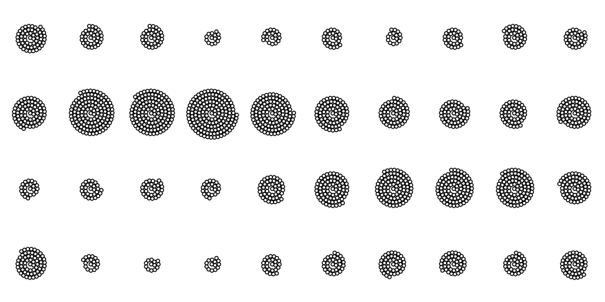

Figure 4.1: Counts during odor B presentation

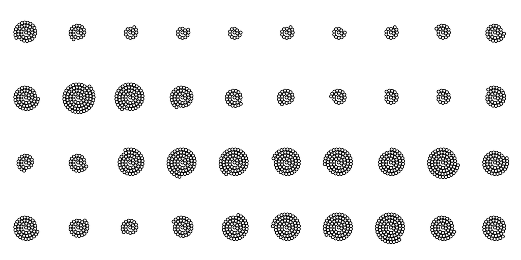

Figure 4.2: Counts during odor C presentation

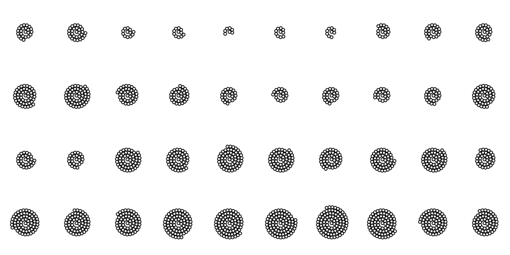

Figure 4.3: Counts during odor D presentation